# Validating a Math Anxiety Scale

[figure not shown]

## Development and Validation of Math Anxiety Questionaire for Korean College Students

## Objective:

- This project was conducted to develop and validate a math anxiety rating scale for korean college students through exploratory factor analysis, reliability analysis, and confirmatry factor analysis.
- Jounral paper link: https://www.researchgate.net/publication/318311512_Development_and_validation_of_the_Korean_mathematics_anxiety_rating_scale_for_college_students

## Context:

- Previous MA studies conducted in South Korea only dealt with subdomains of MA measured from elementary to high school students.
- However, considering that the context in which college students experience MA differs from younger students, it is important to include measurements of MA in relation to decisions about jobs, higher degrees or personal finance.
- To develop this scale, we included previously proposed factors of MA along with additional factors tailored to college students.

## Methods:

- 229 Korean college students were tested.
- Each participant responded to a 7-point likert scale with 55 questions with 5 factors.
- From the data of the initial survey, a 4-factors model with 20 questions was validated through the factor analyses and SEM.

## Four factors of Math Anxiety:

- Abstraction and language: Anxiety caused by the abstract and elusive nature of mathematics and math terminology
- Lack of confidence in math: Lack of confidence or self-efficacy in mathematics
- Math test anxiety : Anxiety or worry caused by being evaluated on math skills in daily life or in learning situations
- Math learning anxiety: Anxiety in learning situations

## The Math Anxiety Scale - 20 Full Questions:

#### Abstraction and language

- Math makes me nervous because its terminology is more abstract.
- I get more nervous when I see symbols such as x and y instead of numbers like 2 or 3.
- Having to prove a mathematical theorem (e. g. triangle theorem, central limit theorem, etc) makes me nervous.
- I feel nervous when I see complicated mathematical symbols such as ∞,π,or χ 2
- I get nervous when I hear mathematical terms whose meaning cannot be inferred.

#### Lack of confidence in math

- I was nervous when checking my math exam results.
- I was nervous and could not concentrate during math exams as I was approaching the time limit.
- I was worried that I would make calculation mistakes during math exams.
- Taking math tests were harder for me cause it required more concentration and attention to detail.

#### Math test anxiety

- I felt nervous in math class.
- I felt nervous and did not enjoy math class because I could not catch up.
- I did not like math class because I did not like my teacher.
- When I was studying math, I was worried about my competence.
- I was nervous and anxious during math exams.

#### Math learning anxiety

- I easily lose confidence in math when encountered with something that seems even just a little bit difficult.
- I think I have no potential for math.
- I cannot study math on my own.
- I would feel doomed if my dream job requires math.
- I will not be able to choose a job which requires high mathematics skills.
- I cannot compete with people who are naturally good at math and if I had to, I would be frustrated.

## Other Findings:

- Female students had higher MA than males.
- Participants majoring in humanities and Social Sciences showed greater MA than those majoring in engineering and natural sciences.

## Implications:

- This research project provides the first validated scale of MA that can be administered to Korean college students.

## Example Codes for Factor Analysis and Descriptive Analysis

```python
%matplotlib inline

import pandas as pd
import numpy as np
import matplotlib.pyplot as plt
import seaborn as sns
from sklearn.datasets import load_iris
from factor_analyzer import FactorAnalyzer
import pingouin as pg
import scipy as scipy
from scipy import stats
```

```python
df = pd.read_csv('exploratory_MA.csv')
```

```python
df.describe()
```

|  | num | id | sex | age | Major_2 | Total Math Anxiety | Q1LearningAnxiety | Q2LearningAnxiety | Q3LearningAnxiety | Q4LearningAnxiety | ... | Q46Language | Q47Abstraction | Q48Language | Q49Language | Q50Abstraction | Q51LackofBasics | Q52LackofBasics | Q53LackofBasics | Q54LackofBasics | Q55LackofBasics |
| --- | --- | --- | --- | --- | --- | --- | --- | --- | --- | --- | --- | --- | --- | --- | --- | --- | --- | --- | --- | --- | --- |
| count | 229.000000 | 229.000000 | 229.000000 | 229.000000 | 226.000000 | 229.000000 | 229.00000 | 229.000000 | 229.000000 | 229.000000 | ... | 229.000000 | 229.000000 | 229.000000 | 229.000000 | 229.000000 | 229.000000 | 229.000000 | 229.000000 | 229.000000 | 229.000000 |
| mean | 115.000000 | 122.388646 | 1.528384 | 22.663755 | 1.221239 | 69.563319 | 3.19214 | 3.183406 | 3.144105 | 2.640351 | ... | 2.838428 | 4.021834 | 2.777293 | 3.593886 | 3.585153 | 4.192140 | 4.296943 | 4.030702 | 4.262009 | 3.109170 |
| std | 66.250786 | 75.386211 | 0.500287 | 2.355573 | 0.416002 | 25.169281 | 1.71621 | 1.696613 | 1.717102 | 1.545379 | ... | 1.637046 | 1.783072 | 1.635197 | 1.918551 | 1.700863 | 1.656388 | 1.716545 | 1.802514 | 1.709467 | 1.801888 |
| min | 1.000000 | 1.000000 | 1.000000 | 18.000000 | 1.000000 | 20.000000 | 1.00000 | 1.000000 | 1.000000 | 1.000000 | ... | 1.000000 | 1.000000 | 1.000000 | 1.000000 | 1.000000 | 1.000000 | 1.000000 | 1.000000 | 1.000000 | 1.000000 |
| 25% | 58.000000 | 58.000000 | 1.000000 | 21.000000 | 1.000000 | 50.000000 | 2.00000 | 2.000000 | 2.000000 | 1.000000 | ... | 2.000000 | 3.000000 | 1.000000 | 2.000000 | 2.000000 | 3.000000 | 3.000000 | 3.000000 | 3.000000 | 2.000000 |
| 50% | 115.000000 | 118.000000 | 2.000000 | 23.000000 | 1.000000 | 68.000000 | 3.00000 | 3.000000 | 3.000000 | 2.000000 | ... | 2.000000 | 4.000000 | 2.000000 | 4.000000 | 4.000000 | 5.000000 | 5.000000 | 4.000000 | 5.000000 | 3.000000 |
| 75% | 172.000000 | 179.000000 | 2.000000 | 24.000000 | 1.000000 | 87.000000 | 5.00000 | 5.000000 | 5.000000 | 3.000000 | ... | 4.000000 | 5.000000 | 4.000000 | 5.000000 | 5.000000 | 5.000000 | 6.000000 | 6.000000 | 5.000000 | 4.000000 |
| max | 229.000000 | 261.000000 | 2.000000 | 37.000000 | 2.000000 | 138.000000 | 7.00000 | 7.000000 | 7.000000 | 7.000000 | ... | 7.000000 | 7.000000 | 7.000000 | 7.000000 | 7.000000 | 7.000000 | 7.000000 | 7.000000 | 7.000000 | 7.000000 |

8 rows × 61 columns

```python
df.head()
```

|  | num | id | sex | age | Major_2 | Major | Total Math Anxiety | Q1LearningAnxiety | Q2LearningAnxiety | Q3LearningAnxiety | ... | Q46Language | Q47Abstraction | Q48Language | Q49Language | Q50Abstraction | Q51LackofBasics | Q52LackofBasics | Q53LackofBasics | Q54LackofBasics | Q55LackofBasics |
| --- | --- | --- | --- | --- | --- | --- | --- | --- | --- | --- | --- | --- | --- | --- | --- | --- | --- | --- | --- | --- | --- |
| 0 | 1 | 1 | 1 | 23 | 2.0 | Engineering | 55 | 4 | 2 | 2 | ... | 1 | 6 | 3 | 1 | 4 | 2 | 5 | 5.0 | 3 | 4 |
| 1 | 2 | 2 | 1 | 24 | 1.0 | Humanitics | 80 | 5 | 4 | 4 | ... | 3 | 3 | 4 | 4 | 5 | 5 | 4 | 4.0 | 5 | 4 |
| 2 | 3 | 3 | 1 | 23 | 1.0 | SocialScience | 66 | 2 | 2 | 2 | ... | 2 | 4 | 2 | 5 | 5 | 5 | 6 | 5.0 | 5 | 4 |
| 3 | 4 | 5 | 1 | 25 | 1.0 | SocialScience | 38 | 1 | 1 | 1 | ... | 1 | 4 | 1 | 1 | 1 | 1 | 2 | 1.0 | 3 | 1 |
| 4 | 5 | 6 | 1 | 19 | 2.0 | NaturalScience | 48 | 4 | 5 | 3 | ... | 2 | 2 | 2 | 1 | 2 | 4 | 2 | 2.0 | 5 | 1 |

5 rows × 62 columns

```python
df.columns
```

```
Index(['num', 'id', 'sex', 'age', 'Major_2', 'Major', 'Total Math Anxiety',
       'Q1LearningAnxiety', 'Q2LearningAnxiety', 'Q3LearningAnxiety',
       'Q4LearningAnxiety', 'Q5LearningComprehend', 'Q6LearningComprehend',
       'Q7LearningComprehend', 'Q8LearningComprehend', 'Q9TestAnxiety',
       'Q10TestAnxiety', 'Q11TestAnxiety', 'Q12TestAnxiety', 'Q13TestAnxiety',
       'Q14TestComprehend', 'Q15TestComprehend', 'Q16TestComprehend',
       'Q17TestComprehend', 'Q18TestComprehend', 'Q19LowMotivPracticality_1',
       'Q20LowMotivPracticality_1', 'Q21LowMotivPracticality_1',
       'Q22LowMotivLearning_1', 'Q23LowMotivPracticality_1',
       'Q24LowMotivLearning', 'Q25LowMotivLearning', 'Q26LowMotivLearning',
       'Q27LowMotivLearning', 'Q28LowMotivLearning', 'Q29LowMotivLearning',
       'Q30LowMotivLearning', 'Q31LowMotivLearning', 'Q32LowMotivLearning',
       'Q33ConfidenceLearning', 'Q34ConfidenceLearning',
       'Q35ConfidenceLearning', 'Q36ConfidenceLearning',
       'Q37ConfidenceLearning', 'Q38ConfidenceCareer', 'Q39ConfidenceCareer',
       'Q40ConfidenceCareer', 'Q41ConfidenceCareer', 'Q42ConfidenceCareer',
       'Q43ConfidenceCareer', 'Q44Abstraction', 'Q45Language', 'Q46Language',
       'Q47Abstraction', 'Q48Language', 'Q49Language', 'Q50Abstraction',
       'Q51LackofBasics', 'Q52LackofBasics', 'Q53LackofBasics',
       'Q54LackofBasics', 'Q55LackofBasics'],
      dtype='object')
```

```python
# Dropping unnecessary columns
df.drop(['num', 'id', 'sex', 'age', 'Major_2', 'Major', 'Total Math Anxiety'],axis=1,inplace=True)
```

```python
# Dropping missing values rows
df.dropna(inplace=True)
```

```python
df.info()
```

```
<class 'pandas.core.frame.DataFrame'>
Int64Index: 229 entries, 0 to 228
Data columns (total 55 columns):
 #   Column                     Non-Null Count  Dtype
---  ------                     --------------  -----
 0   Q1LearningAnxiety          229 non-null    int64
 1   Q2LearningAnxiety          229 non-null    int64
 2   Q3LearningAnxiety          229 non-null    int64
 3   Q4LearningAnxiety          229 non-null    float64
 4   Q5LearningComprehend       229 non-null    int64
 5   Q6LearningComprehend       229 non-null    int64
 6   Q7LearningComprehend       229 non-null    int64
 7   Q8LearningComprehend       229 non-null    int64
 8   Q9TestAnxiety              229 non-null    float64
 9   Q10TestAnxiety             229 non-null    float64
```

[output cut: 47 more lines]

## Exploratory Factor Analysis

### Adequacy Test (sphericity checks)

```python
# Evaluate the “factorability” of our dataset using Bartlett’s Test and Kaiser-Meyer-Olkin Test

from factor_analyzer.factor_analyzer import calculate_bartlett_sphericity
chi_square_value,p_value=calculate_bartlett_sphericity(df)
chi_square_value, p_value
```

```
(11718.175311153227, 0.0)
```

```python
# Evaluate the “factorability” of our dataset using Kaiser-Meyer-Olkin Test

from factor_analyzer.factor_analyzer import calculate_kmo
kmo_all,kmo_model=calculate_kmo(df)
```

```python
kmo_model
```

```
0.9639056529031022
```

```python
# Choosing the Number of Factors
# For choosing the number of factors, you can use the Kaiser criterion and scree plot. Both are based on eigenvalues.
# Create factor analysis object and perform factor analysis

# Check Eigenvalues
fa = FactorAnalyzer()
fa.fit(df)
ev, v = fa.get_eigenvalues()
ev_t = pd.DataFrame(ev, columns = ['Eigenvalues'])
ev_t
```

|  | Eigenvalues |
| --- | --- |
| 0 | 27.391755 |
| 1 | 3.612655 |
| 2 | 1.880462 |
| 3 | 1.672710 |
| 4 | 1.503056 |
| 5 | 1.201514 |
| 6 | 1.086040 |
| 7 | 0.993702 |
| 8 | 0.957497 |
| 9 | 0.872573 |
| 10 | 0.776133 |
| 11 | 0.720185 |
| 12 | 0.683666 |
| 13 | 0.643418 |
| 14 | 0.613738 |
| 15 | 0.560598 |
| 16 | 0.553684 |
| 17 | 0.528519 |
| 18 | 0.484314 |
| 19 | 0.456447 |
| 20 | 0.442070 |
| 21 | 0.426772 |
| 22 | 0.406434 |
| 23 | 0.403604 |
| 24 | 0.367841 |
| 25 | 0.363994 |
| 26 | 0.331401 |
| 27 | 0.321612 |
| 28 | 0.302557 |
| 29 | 0.286858 |
| 30 | 0.284512 |
| 31 | 0.262377 |
| 32 | 0.251835 |
| 33 | 0.241127 |
| 34 | 0.238504 |
| 35 | 0.224634 |
| 36 | 0.213807 |
| 37 | 0.203171 |
| 38 | 0.194905 |
| 39 | 0.188650 |
| 40 | 0.174648 |
| 41 | 0.169871 |
| 42 | 0.162672 |
| 43 | 0.150617 |
| 44 | 0.148089 |
| 45 | 0.138952 |
| 46 | 0.126956 |
| 47 | 0.120163 |
| 48 | 0.116515 |
| 49 | 0.109902 |
| 50 | 0.103082 |
| 51 | 0.097246 |
| 52 | 0.091401 |
| 53 | 0.074393 |
| 54 | 0.066163 |

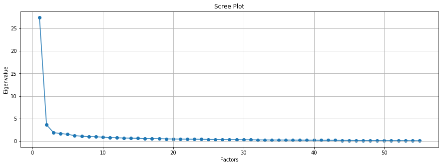

```python
# Create scree plot using matplotlib
plt.figure(figsize = (15,5))
plt.scatter(range(1,df.shape[1]+1),ev)
plt.plot(range(1,df.shape[1]+1),ev)
plt.title('Scree Plot')
plt.xlabel('Factors')
plt.ylabel('Eigenvalue')
plt.grid()
plt.show()
```

```python
var = fa.get_factor_variance()
var_table = pd.DataFrame(var, index = ['SS Loadings','Proportion Var','Cumulative Var'])
var_table
```

|  | 0 | 1 | 2 | 3 | 4 | 5 | 6 |
| --- | --- | --- | --- | --- | --- | --- | --- |
| SS Loadings | 5.110394 | 4.803489 | 3.386576 | 3.184489 | 2.332558 | 2.325014 | 2.095103 |
| Proportion Var | 0.092916 | 0.087336 | 0.061574 | 0.057900 | 0.042410 | 0.042273 | 0.038093 |
| Cumulative Var | 0.092916 | 0.180252 | 0.241827 | 0.299726 | 0.342136 | 0.384409 | 0.422502 |

So, Total 42% cumulative Variance explained by the 7 factors.

```python
# Create factor analysis object and perform factor analysis
fa = FactorAnalyzer()
# A direct oblimin rotation method is taken, because the factors are designed not to be conceptually independent.
fa.set_params(n_factors=7, rotation='oblimin')
fa.fit(df)
loadings = fa.loadings_
fa.loadings_
efa1 = pd.DataFrame(fa.loadings_, columns = ['factor1','factor2','factor3','factor4','factor5','factor6','factor7'],  index = ['Q1LearningAnxiety',	'Q2LearningAnxiety',	'Q3LearningAnxiety',	'Q4LearningAnxiety',	'Q5LearningComprehend',	'Q6LearningComprehend',	'Q7LearningComprehend',	'Q8LearningComprehend',	'Q9TestAnxiety',	'Q10TestAnxiety',	'Q11TestAnxiety',	'Q12TestAnxiety',	'Q13TestAnxiety',	'Q14TestComprehend',	'Q15TestComprehend',	'Q16TestComprehend',	'Q17TestComprehend',	'Q18TestComprehend',	'Q19LowMotivPracticality',	'Q20LowMotivPracticality',	'Q21LowMotivPracticality',	'Q22LowMotivLearning',	'Q23LowMotivPracticality',	'Q24LowMotivLearning',	'Q25LowMotivLearning',	'Q26LowMotivLearning',	'Q27LowMotivLearning',	'Q28LowMotivLearning',	'Q29LowMotivLearning',	'Q30LowMotivLearning',	'Q31LowMotivLearning',	'Q32LowMotivLearning',	'Q33ConfidenceLearning',	'Q34ConfidenceLearning',	'Q35ConfidenceLearning',	'Q36ConfidenceLearning',	'Q37ConfidenceLearning',	'Q38ConfidenceCareer',	'Q39ConfidenceCareer',	'Q40ConfidenceCareer',	'Q41ConfidenceCareer',	'Q42ConfidenceCareer',	'Q43ConfidenceCareer',	'Q44Abstraction',	'Q45Language',	'Q46Language',	'Q47Abstraction',	'Q48Language',	'Q49Language',	'Q50Abstraction',	'Q51LackofBasics',	'Q52LackofBasics',	'Q53LackofBasics',	'Q54LackofBasics',	'Q55LackofBasics'])
efa1
```

|  | factor1 | factor2 | factor3 | factor4 | factor5 | factor6 | factor7 |
| --- | --- | --- | --- | --- | --- | --- | --- |
| Q1LearningAnxiety | 0.149491 | 0.109368 | -0.012851 | 0.210928 | 0.058018 | 0.416954 | 0.070927 |
| Q2LearningAnxiety | 0.178719 | 0.171406 | -0.148101 | 0.268092 | 0.116722 | 0.420284 | -0.086679 |
| Q3LearningAnxiety | 0.068942 | 0.080036 | 0.005352 | 0.235076 | 0.171842 | 0.518065 | -0.088628 |
| Q4LearningAnxiety | 0.109830 | 0.191783 | 0.064896 | 0.140912 | 0.175518 | 0.260020 | -0.224528 |
| Q5LearningComprehend | 0.136373 | 0.102354 | 0.082782 | 0.033627 | 0.087130 | 0.574392 | 0.099267 |
| Q6LearningComprehend | 0.142003 | 0.096249 | 0.188136 | 0.049710 | 0.060866 | 0.426245 | 0.228237 |
| Q7LearningComprehend | -0.007935 | 0.024004 | 0.078288 | -0.097812 | 0.119226 | 0.529122 | 0.448161 |
| Q8LearningComprehend | 0.094953 | 0.199264 | 0.034798 | 0.041490 | 0.036821 | 0.458508 | 0.255870 |
| Q9TestAnxiety | 0.063666 | 0.688358 | 0.010913 | 0.046362 | 0.043027 | 0.006234 | 0.155614 |
| Q10TestAnxiety | -0.082478 | 0.878356 | -0.047694 | 0.043557 | 0.057181 | -0.025633 | -0.014702 |
| Q11TestAnxiety | 0.239798 | 0.413997 | 0.074351 | 0.226165 | 0.005888 | 0.048729 | 0.066550 |
| Q12TestAnxiety | 0.053601 | 0.444019 | 0.125225 | 0.247525 | -0.023991 | 0.152993 | 0.097517 |
| Q13TestAnxiety | 0.053788 | 0.551269 | -0.119562 | 0.058403 | 0.073656 | 0.087495 | 0.138359 |
| Q14TestComprehend | -0.006919 | 0.812243 | 0.022992 | -0.031813 | 0.024363 | -0.055889 | -0.046440 |
| Q15TestComprehend | 0.078545 | 0.592905 | -0.036532 | -0.012561 | -0.128009 | -0.013433 | 0.260845 |
| Q16TestComprehend | 0.155606 | 0.702865 | 0.056627 | -0.070106 | -0.026756 | 0.097143 | -0.002792 |
| Q17TestComprehend | 0.027658 | 0.589563 | 0.264488 | 0.036712 | -0.001324 | 0.112545 | 0.020101 |
| Q18TestComprehend | -0.028841 | 0.629080 | 0.134950 | -0.120772 | 0.111126 | 0.154661 | -0.062887 |
| Q19LowMotivPracticality | 0.139202 | -0.057768 | 0.755756 | 0.025158 | 0.113083 | -0.020483 | -0.042491 |
| Q20LowMotivPracticality | -0.002216 | 0.071239 | 0.870865 | -0.023896 | 0.055571 | 0.020157 | 0.013402 |
| Q21LowMotivPracticality | 0.061844 | 0.068004 | 0.828273 | -0.015340 | 0.016895 | 0.016470 | 0.094432 |
| Q22LowMotivLearning | 0.047953 | 0.012423 | 0.143528 | 0.696099 | -0.034953 | -0.035563 | 0.047201 |
| Q23LowMotivPracticality | 0.019660 | -0.043555 | 0.641011 | 0.304718 | 0.023751 | -0.003781 | 0.014518 |
| Q24LowMotivLearning | 0.119862 | -0.008251 | 0.109864 | 0.493062 | 0.062606 | 0.282547 | -0.118656 |
| Q25LowMotivLearning | -0.039321 | 0.027663 | -0.025351 | 0.800819 | 0.159603 | 0.042612 | 0.031179 |
| Q26LowMotivLearning | -0.016729 | 0.044739 | 0.143722 | 0.625239 | 0.035807 | 0.058173 | 0.036715 |
| Q27LowMotivLearning | 0.034608 | 0.133640 | 0.280077 | 0.388626 | -0.000841 | 0.277160 | -0.089392 |
| Q28LowMotivLearning | 0.049476 | 0.006898 | 0.469508 | 0.119616 | 0.133577 | 0.047953 | -0.119965 |
| Q29LowMotivLearning | -0.083290 | 0.252070 | 0.243667 | 0.328428 | -0.091597 | 0.056434 | 0.046762 |
| Q30LowMotivLearning | 0.329650 | 0.035282 | 0.200403 | 0.187106 | 0.207975 | 0.019605 | -0.175225 |
| Q31LowMotivLearning | 0.229378 | -0.140547 | -0.019283 | 0.522931 | -0.162091 | -0.005804 | 0.118555 |
| Q32LowMotivLearning | 0.459536 | 0.063268 | 0.160167 | -0.026249 | -0.087112 | 0.149914 | -0.162566 |
| Q33ConfidenceLearning | 0.124896 | 0.035035 | 0.152042 | 0.191747 | 0.021650 | 0.373670 | -0.153416 |
| Q34ConfidenceLearning | 0.354986 | -0.028346 | 0.194820 | 0.231121 | 0.075420 | 0.198791 | 0.025788 |
| Q35ConfidenceLearning | 0.712969 | 0.065784 | 0.207136 | 0.023196 | -0.093531 | 0.106556 | -0.068466 |
| Q36ConfidenceLearning | 0.436063 | -0.059945 | 0.096181 | 0.229318 | 0.059823 | 0.107872 | 0.010257 |
| Q37ConfidenceLearning | 0.634384 | -0.004804 | 0.179320 | 0.121503 | -0.060838 | 0.158607 | -0.050310 |
| Q38ConfidenceCareer | 0.749047 | -0.027576 | 0.090955 | -0.015539 | 0.062259 | 0.038716 | 0.111177 |
| Q39ConfidenceCareer | 0.586877 | -0.014950 | 0.089145 | 0.050781 | 0.193012 | -0.005927 | 0.107518 |
| Q40ConfidenceCareer | 0.767937 | 0.114983 | -0.113480 | -0.021744 | -0.018837 | 0.043461 | 0.055638 |
| Q41ConfidenceCareer | 0.590892 | 0.089829 | 0.081969 | 0.069080 | 0.133229 | -0.009454 | 0.048010 |
| Q42ConfidenceCareer | 0.602736 | 0.069091 | 0.093491 | -0.036325 | 0.124223 | 0.044084 | 0.207985 |
| Q43ConfidenceCareer | 0.680324 | 0.069180 | 0.049521 | 0.064656 | 0.193172 | -0.028656 | 0.067081 |
| Q44Abstraction | 0.326418 | 0.320515 | -0.025930 | 0.034508 | 0.403295 | -0.023211 | -0.171792 |
| Q45Language | 0.309669 | 0.154522 | 0.004751 | 0.148660 | 0.423070 | 0.004127 | -0.024933 |
| Q46Language | 0.046798 | 0.019761 | 0.119339 | 0.113005 | 0.588324 | -0.017461 | 0.083977 |
| Q47Abstraction | 0.222222 | 0.128032 | 0.142310 | 0.167611 | 0.267917 | -0.137045 | 0.298413 |
| Q48Language | -0.049222 | 0.071701 | 0.152009 | -0.029017 | 0.743393 | 0.050696 | 0.036463 |
| Q49Language | 0.093701 | -0.046124 | 0.072716 | 0.033046 | 0.644257 | 0.147880 | 0.114035 |
| Q50Abstraction | 0.043246 | 0.076038 | 0.050186 | 0.171680 | 0.355009 | 0.131915 | 0.301435 |
| Q51LackofBasics | 0.026275 | 0.100767 | 0.082702 | 0.127299 | 0.116095 | 0.113432 | 0.626193 |
| Q52LackofBasics | 0.193641 | 0.101907 | 0.013593 | 0.031014 | 0.114939 | 0.139203 | 0.514855 |
| Q53LackofBasics | 0.226853 | 0.333876 | 0.082241 | -0.011185 | 0.030927 | 0.132992 | 0.248142 |
| Q54LackofBasics | 0.185851 | 0.187787 | 0.047166 | 0.055262 | 0.091148 | -0.014417 | 0.600200 |
| Q55LackofBasics | 0.394781 | -0.051311 | 0.009653 | 0.334856 | 0.108624 | 0.124330 | 0.139321 |

#### Factor 1 has high factor loadings for Q35 - Q43 (Lack of Confidence in Math).

#### Factor 2 has high factor loadings for Q9 - Q18 (Math Test Anxiety).

#### Factor 5 has high factor loadings for Q44 - Q50 (Abstraction and Language).

#### Factor 6 has high factor loadings for Q1 - Q8 (Math Learning Anxiety).

#### Factor 3, 4, and 7 do not make a clear variable with high loadings and are not easily interpretable.

### With the consideration of question contents, 4 main factors and 20 items were derived:

#### 1. Math Learning Anxiety: Q1, Q3, Q4, and Q5

#### 2. Math Test Anxiety: Q9, Q10, Q13, Q15, and Q18

#### 3. Lack of Confidence in Math: Q34, Q35, Q36, Q38, Q39, and Q40

#### 4. Abstraction and Language: Q45, Q46, Q47, Q49, and Q50

### Examining Internal Consistency

```python
df1 = pd.read_csv('confirmatory_MA.csv')
```

```python
# Dropping unnecessary columns
df1.drop(['num', 'id', 'sex', 'age', 'Major_2', 'Major', 'Total Math Anxiety'],axis=1,inplace=True)
```

```python
df1.info()
```

```
<class 'pandas.core.frame.DataFrame'>
RangeIndex: 229 entries, 0 to 228
Data columns (total 20 columns):
 #   Column                  Non-Null Count  Dtype
---  ------                  --------------  -----
 0   Q1LearningAnxiety       229 non-null    int64
 1   Q3LearningAnxiety       229 non-null    int64
 2   Q4LearningAnxiety       229 non-null    float64
 3   Q5LearningComprehend    229 non-null    int64
 4   Q9TestAnxiety           229 non-null    float64
 5   Q10TestAnxiety          229 non-null    float64
 6   Q13TestAnxiety          229 non-null    int64
 7   Q15TestComprehend       229 non-null    int64
 8   Q18TestComprehend       229 non-null    float64
 9   Q34ConfidenceLearning   229 non-null    float64
 10  Q35ConfidenceLearning   229 non-null    int64
 11  Q36ConfidenceLearning   229 non-null    int64
 12  Q38ConfidenceCareer     229 non-null    int64
 13  Q39ConfidenceCareer     229 non-null    int64
 14  Q40ConfidenceCareer     229 non-null    int64
 15  Q45AbstractionLanguage  229 non-null    int64
 16  Q46AbstractionLanguage  229 non-null    int64
 17  Q47AbstractionLanguage  229 non-null    int64
 18  Q49AbstractionLanguage  229 non-null    int64
 19  Q50AbstractionLanguage  229 non-null    int64
dtypes: float64(5), int64(15)
memory usage: 35.9 KB
```

```python
# Calculate Cronback's alpha for the entire scale
CA_entire = pg.cronbach_alpha(data=df1)
```

```
(0.9500359318600095, array([0.94 , 0.959]))
```

```python
# Calculate Cronback's alpha for the subscales

##### EDIT by FOR
F1_Learning = df1.iloc[:,0:4]
F2_Test = df1.iloc[:,4:9]
F3_Confidence = df1.iloc[:,9:15]
F4_Abstraction = df1.iloc[:,15:20]

CA_F1 = pg.cronbach_alpha(data=F1_Learning)
CA_F2 = pg.cronbach_alpha(data=F2_Test)
CA_F3 = pg.cronbach_alpha(data=F3_Confidence)
CA_F4 = pg.cronbach_alpha(data=F4_Abstraction)

CA_F1_alpha = float(CA_F1[0])
CA_F2_alpha = float(CA_F2[0])
CA_F3_alpha = float(CA_F3[0])
CA_F4_alpha = float(CA_F4[0])

CA_subsets = [CA_F1_alpha, CA_F2_alpha, CA_F3_alpha, CA_F4_alpha]
CA_subsets
```

```
[0.8568801807771599,
 0.8642393034230639,
 0.9171935234413349,
 0.8985077098577176]
```

#### The internal consistencies of the entire scale and all the subsets of factors are high.

#### Cronback's alpha values for both the entire scale and the subsets are greater than .7

## Confirmatory Factor Analysis

```python
from factor_analyzer import (ConfirmatoryFactorAnalyzer, ModelSpecificationParser)

model_dict = {"F1": ["Q1LearningAnxiety", "Q3LearningAnxiety", "Q4LearningAnxiety", "Q5LearningComprehend"], "F2": ["Q9TestAnxiety","Q10TestAnxiety","Q13TestAnxiety","Q15TestComprehend","Q18TestComprehend"],
              "F3": ["Q34ConfidenceLearning","Q35ConfidenceLearning","Q36ConfidenceLearning","Q38ConfidenceCareer","Q39ConfidenceCareer","Q40ConfidenceCareer"], "F4": ["Q45AbstractionLanguage", "Q46AbstractionLanguage", "Q47AbstractionLanguage","Q49AbstractionLanguage","Q50AbstractionLanguage"]}

model_spec = ModelSpecificationParser.parse_model_specification_from_dict(df, model_dict)

cfa = ConfirmatoryFactorAnalyzer(model_spec, disp=False)

cfa.fit(df1.values)

cfa.loadings_
```

```
array([[1.06296211, 0.        , 0.        , 0.        ],
       [1.09370362, 0.        , 0.        , 0.        ],
       [0.8636373 , 0.        , 0.        , 0.        ],
       [1.15005012, 0.        , 0.        , 0.        ],
       [0.        , 1.1723166 , 0.        , 0.        ],
       [0.        , 1.15829141, 0.        , 0.        ],
       [0.        , 0.98816981, 0.        , 0.        ],
       [0.        , 0.90355268, 0.        , 0.        ],
       [0.        , 1.01233621, 0.        , 0.        ],
       [0.        , 0.        , 0.93443801, 0.        ],
       [0.        , 0.        , 1.13529343, 0.        ],
       [0.        , 0.        , 0.8411517 , 0.        ],
       [0.        , 0.        , 1.21145668, 0.        ],
       [0.        , 0.        , 1.10569117, 0.        ],
       [0.        , 0.        , 1.06182334, 0.        ],
       [0.        , 0.        , 0.        , 0.96564251],
       [0.        , 0.        , 0.        , 0.97634803],
       [0.        , 0.        , 0.        , 1.06217944],
       [0.        , 0.        , 0.        , 1.18622966],
       [0.        , 0.        , 0.        , 1.03140576]])
```

```python
cfa.factor_varcovs_
```

```
array([[1.        , 0.30762797, 0.42919985, 0.35481259],
       [0.30762797, 1.        , 0.2626196 , 0.3048013 ],
       [0.42919985, 0.2626196 , 1.        , 0.45721929],
       [0.35481259, 0.3048013 , 0.45721929, 1.        ]])
```

```python
cfa.get_standard_errors()
```

```
(array([[0.08209936, 0.        , 0.        , 0.        ],
        [0.08175529, 0.        , 0.        , 0.        ],
        [0.07835697, 0.        , 0.        , 0.        ],
        [0.08502426, 0.        , 0.        , 0.        ],
        [0.        , 0.08277955, 0.        , 0.        ],
        [0.        , 0.08465236, 0.        , 0.        ],
        [0.        , 0.08291931, 0.        , 0.        ],
        [0.        , 0.0805852 , 0.        , 0.        ],
        [0.        , 0.08469518, 0.        , 0.        ],
        [0.        , 0.        , 0.07429561, 0.        ],
        [0.        , 0.        , 0.08011749, 0.        ],
        [0.        , 0.        , 0.07345965, 0.        ],
        [0.        , 0.        , 0.08138681, 0.        ],
        [0.        , 0.        , 0.08255603, 0.        ],
        [0.        , 0.        , 0.08401856, 0.        ],
        [0.        , 0.        , 0.        , 0.07430908],
        [0.        , 0.        , 0.        , 0.07761842],
        [0.        , 0.        , 0.        , 0.08176365],
        [0.        , 0.        , 0.        , 0.08487043],
        [0.        , 0.        , 0.        , 0.0791804 ]]),
 array([0.09643741, 0.09466737, 0.09323099, 0.10208667, 0.0929485 ,
        0.09868212, 0.10119025, 0.09819784, 0.10542538, 0.07840262,
        0.08347144, 0.08108769, 0.08271096, 0.09261422, 0.09994596,
        0.07744302, 0.08606591, 0.09377731, 0.09680484, 0.08780834]))
```

```python
cfa.transform(df1.values)
```

```
array([[-4.64755532e-01, -9.09054849e-01, -8.57410563e-01,
        -8.09760763e-01],
       [ 1.09198074e+00,  7.45477198e-02,  7.59643591e-01,
         2.18525498e-01],
       [-8.61146202e-01, -6.13319803e-01,  3.70556047e-01,
         2.33769923e-01],
       [-2.06847136e+00, -1.96727138e+00, -6.88079861e-01,
        -1.73470466e+00],
       [-1.15344418e-01, -7.55235318e-01, -1.33380081e+00,
        -1.53251423e+00],
       [-2.06847136e+00, -2.07047413e+00, -2.13467759e+00,
        -2.27689137e+00],
       [-1.12359108e+00, -1.64864902e+00, -1.19775408e+00,
        -7.72892663e-01],
       [-1.36432505e+00, -1.14871867e+00, -2.13467759e+00,
        -2.27689137e+00],
       [ 1.02861437e+00,  4.55876519e-01,  5.83554374e-02,
        -5.96081106e-01],
       [-1.56529252e+00,  5.59079267e-01, -1.74352455e+00,
        -1.91543357e+00],
       [-1.12359108e+00, -1.94353075e+00, -8.06601042e-01,
        -1.70932579e+00],
       [-7.97779831e-01, -4.29599163e-01, -1.60207788e+00,
        -1.52436960e+00],
       [-2.06847136e+00, -1.99541067e+00, -2.13467759e+00,
        -1.52557658e+00],
       [-1.80602649e+00, -4.83487928e-01, -2.00429324e+00,
        -2.27689137e+00],
       [-1.54358161e+00,  2.25456336e+00, -1.20644910e+00,
        -4.41203163e-01],
       [-9.46223475e-01, -1.64864902e+00, -1.19775408e+00,
        -5.62557600e-01],
       [-2.06847136e+00, -2.88005589e+00, -2.13467759e+00,
        -2.09616247e+00],
       [-8.55624291e-03,  3.18988789e-01, -3.61006514e-01,
        -2.08906267e+00],
       [ 3.91489730e-01,  2.25456336e+00,  2.46089066e+00,
        -3.20079098e-02],
       [-1.56340355e+00, -2.88005589e+00, -1.87390890e+00,
        -2.27689137e+00],
```

[output cut: 403 more lines]

```
        -3.26843660e-01],
       [-1.78710789e-01, -1.00700562e+00, -1.09245789e-01,
         2.04325907e-01],
       [ 1.50878390e-01, -5.09690403e-01, -1.71617542e-01,
        -3.04337295e-01],
       [ 4.76346819e-01,  9.52765084e-01,  2.13351817e-01,
         7.79301225e-01],
       [ 2.15086226e+00,  1.15894037e+00,  2.45677248e+00,
         1.36211124e+00],
       [ 2.35955663e-01, -1.47548151e+00, -4.66735897e-01,
        -2.09181065e-03],
       [ 1.96817057e+00,  1.28786975e+00,  1.00110078e+00,
         1.88136662e+00],
       [ 1.70916082e+00,  1.58033883e+00,  1.79205894e+00,
         1.19225168e+00]])
```

## Exploratory analysis to test the validity of the Math Anxiety scale

```python
df_e = pd.read_csv('confirmatory_MA.csv')
df_e
```

|  | num | id | sex | age | Majortwo | Major | Total Math Anxiety | Q1LearningAnxiety | Q3LearningAnxiety | Q4LearningAnxiety | ... | Q35ConfidenceLearning | Q36ConfidenceLearning | Q38ConfidenceCareer | Q39ConfidenceCareer | Q40ConfidenceCareer | Q45AbstractionLanguage | Q46AbstractionLanguage | Q47AbstractionLanguage | Q49AbstractionLanguage | Q50AbstractionLanguage |
| --- | --- | --- | --- | --- | --- | --- | --- | --- | --- | --- | --- | --- | --- | --- | --- | --- | --- | --- | --- | --- | --- |
| 0 | 1 | 1 | Male | 23 | Engineering&NaturalSci | Engineering | 55 | 4 | 2 | 3.0 | ... | 4 | 2 | 2 | 1 | 3 | 1 | 1 | 6 | 1 | 4 |
| 1 | 2 | 2 | Male | 24 | Humanitics&SocialSci | Humanitics | 80 | 5 | 4 | 3.0 | ... | 4 | 3 | 5 | 4 | 4 | 3 | 3 | 3 | 4 | 5 |
| 2 | 3 | 3 | Male | 23 | Humanitics&SocialSci | SocialScience | 66 | 2 | 2 | 2.0 | ... | 4 | 5 | 4 | 3 | 3 | 2 | 2 | 4 | 5 | 5 |
| 3 | 4 | 5 | Male | 25 | Humanitics&SocialSci | SocialScience | 38 | 1 | 1 | 1.0 | ... | 6 | 1 | 1 | 2 | 4 | 1 | 1 | 4 | 1 | 1 |
| 4 | 5 | 6 | Male | 19 | Engineering&NaturalSci | NaturalScience | 48 | 4 | 3 | 2.0 | ... | 2 | 2 | 2 | 1 | 1 | 2 | 2 | 2 | 1 | 2 |
| ... | ... | ... | ... | ... | ... | ... | ... | ... | ... | ... | ... | ... | ... | ... | ... | ... | ... | ... | ... | ... | ... |
| 224 | 225 | 168 | Female | 22 | Humanitics&SocialSci | SocialScience | 83 | 5 | 1 | 4.0 | ... | 3 | 4 | 4 | 3 | 3 | 3 | 4 | 5 | 5 | 4 |
| 225 | 226 | 169 | Female | 21 | Humanitics&SocialSci | SocialScience | 107 | 5 | 5 | 6.0 | ... | 7 | 5 | 6 | 5 | 6 | 3 | 3 | 7 | 6 | 5 |
| 226 | 227 | 170 | Female | 21 | Humanitics&SocialSci | SocialScience | 60 | 4 | 5 | 1.0 | ... | 3 | 3 | 2 | 3 | 3 | 3 | 2 | 6 | 3 | 3 |
| 227 | 228 | 171 | Female | 22 | Humanitics&SocialSci | SocialScience | 100 | 5 | 6 | 2.0 | ... | 3 | 3 | 5 | 4 | 5 | 2 | 6 | 7 | 6 | 6 |
| 228 | 229 | 172 | Female | 25 | Humanitics&SocialSci | SocialScience | 103 | 5 | 4 | 5.0 | ... | 5 | 5 | 6 | 3 | 6 | 5 | 2 | 6 | 5 | 5 |

229 rows × 27 columns

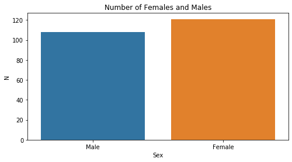

```python
plt.figure(figsize=(8,4))
sns.countplot(x=df_e['sex'])
plt.title('Number of Females and Males')
plt.xlabel('Sex')
plt.ylabel('N')
plt.show()
```

```python
#An independent t test comparing males and females
#Levene's test for equality of variances

stats.levene(df_e['Total Math Anxiety'][df_e['sex'] == 'Male'],
             df_e['Total Math Anxiety'][df_e['sex'] == 'Female'])
```

```
LeveneResult(statistic=0.5668449979436155, pvalue=0.45229544104443964)
```

```python
#An independent t test
scipy.stats.ttest_ind(Males, Females, axis=0, equal_var=True, nan_policy='propagate')
```

```
Ttest_indResult(statistic=-2.867873624252081, pvalue=0.004521621725101069)
```

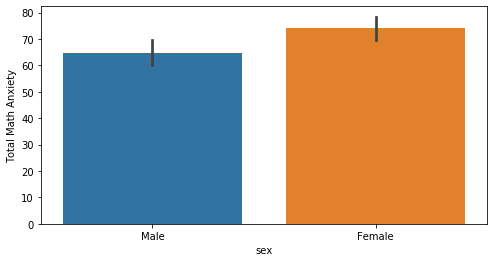

```python
plt.figure(figsize=(8,4))
sns.barplot(x = 'sex',y = 'Total Math Anxiety',data = df_e)
plt.show()
```

#### - An independent t-test revealed that males had less math anxiety than females.

## College Majors & Math Anxiety

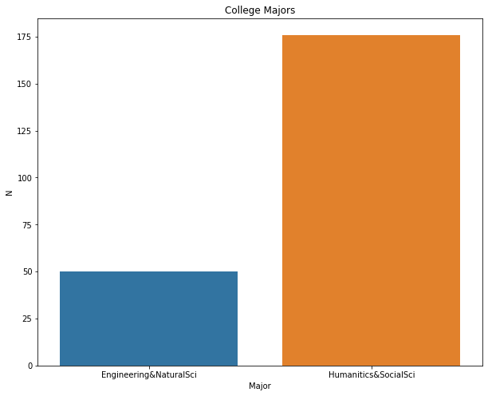

```python
plt.figure(figsize=(10,8))
sns.countplot(x=df_e['Majortwo'])
plt.title('College Majors')
plt.xlabel('Major')
plt.ylabel('N')
plt.show()
```

```python
#An independent t test comparing two majors
#Levene's test for equality of variances
stats.levene(df_e['Total Math Anxiety'][df_e['Majortwo'] == 'Humanitics&SocialSci'],
             df_e['Total Math Anxiety'][df_e['Majortwo'] == 'Engineering&NaturalSci'])
```

```
LeveneResult(statistic=5.0869100794257935, pvalue=0.02507331668240991)
```

```python
#An independent t test
scipy.stats.ttest_ind(Human, Engi, axis=0, equal_var=False, nan_policy='propagate')
```

```
Ttest_indResult(statistic=5.656743718219696, pvalue=1.6011542249545797e-07)
```

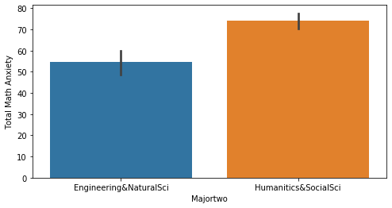

```python
plt.figure(figsize=(8,4))
sns.barplot(x = 'Majortwo',y = 'Total Math Anxiety',data = df_e)
plt.show()
```

#### - An independent t-test revealed that people majoring Engineering or Natual Science had less math anxiety than those majoring in Humanitics or Social Science.